# manuscript-results-possibilities

Lukáš ‘hejtmy’ Hejtmánek

18/08/2020

```r
library(multcomp)
library(car)
library(navr)
library(plotly)
library(knitr)
library(nlme)
library(tidyverse)

DATA_DIR <- "E:/OneDrive/NUDZ/projects/HCENAT/Data/"
RELATIVE_DIR <- ".."

sapply(list.files("../functions", full.names = TRUE, recursive = TRUE), source)
source("../scripts/load-data.R")
df_all <- df_all %>% arrange(participant, pulse_id)
```

## Modelování HRF

Celkově jsem uvažoval o dvou metodách modelování HRF odpovědí pro dva typy trialů. Buď modelovat zvlášť, nebo modelovat odpovědi po celou dobu experimentu a následně je rozdělit.

Toto je výsledek modelování zvlášť. Je možné vidět “překryvy” ve chvíli, kdy trial končí tak hrf předchozího ještě dobíhá.

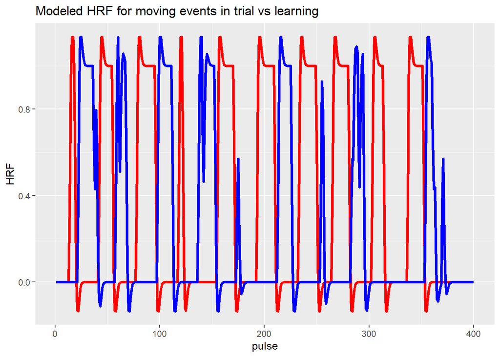

toto je výsledek “labelování” zvlášť. Tzn. movement je modelován po celou dobu experimentu a “vybarven” posléze podle typu trialu

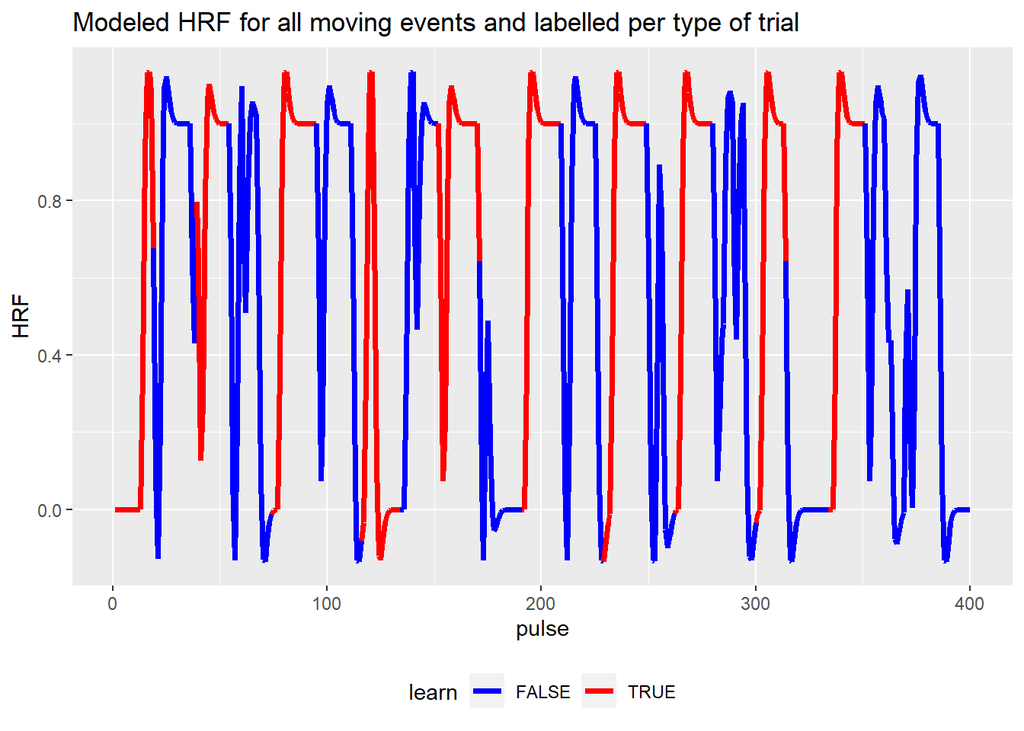

Pro analýzy používám ten první způsob, ale není problém přehodit to na ten druhý. Nevím, co je typičtější u takhle “překrývajících” se eventů.

## Hromadné GLM

Jeden z navrhovaných způsobů bylo očekávat, že autokorelace bude u všech participantů stejná a “ignorovat ji”. Generovat pak pomocí general linear modelu koeficienty pro jednotlivé prediktory pro participanta zvlášť a následně tyto koeficienty porovnat. Podobně to dělá FSL (i když autokorelaci zohledňuje) - tedy modeluje participanty pomocí GLM zvlášť a následně pomocí bayese porovnává beta koeficienty mezi skupinami nebo vůči nule. Je to mnohem rychlejší než mixed/hierarchical modeling.

Tímto postupem pro komponentu MOT 33 pak dostaneme následné beta koeficienty.

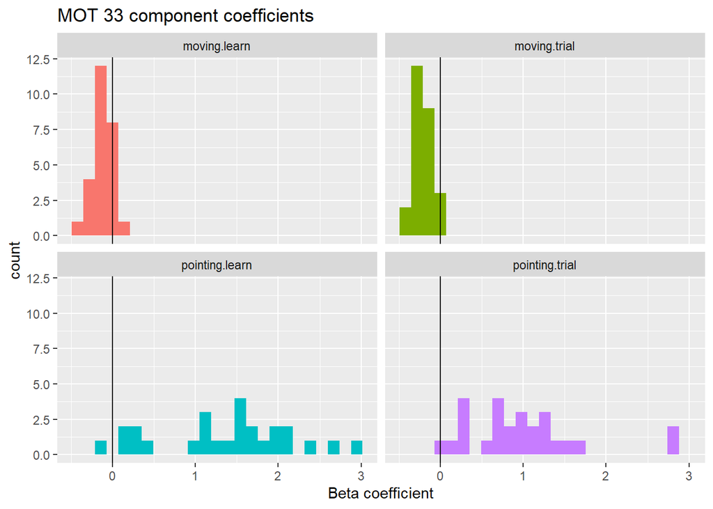

```r
df_res %>%
  pivot_longer(cols=-participant) %>%
  ggplot(aes(value, fill=name)) + geom_histogram(bins = 25) +
    facet_wrap(~name) + geom_vline(xintercept = 0) +
    labs(title = "MOT 33 component coefficients",
         x = "Beta coefficient") +
    guides(fill=FALSE)
```

Je tam bohužel vidět, že zatím co moving se pohybuje cca s normálním rozdělením, pointing je “all over the place”, takže nějaké bayes metody nebo boostraping by asi byl pro následnou analýzu efektivnější.

## Mixed modely

Následující postup jsem objevil jako primární doporučení řešení autokorelací a následně jsem jej i našel jako zdokumentovaný v tomoto preprintu [preprintu](https://psyarxiv.com/crx4m/). Stejnou metodiku používá i balík [fmri](https://cran.r-project.org/web/packages/fmri/fmri.pdf) pro své modelování. To je balík pod Weierstrass Institute for Applied Analysis and Stochastics v Berlíně (http://www.wias-berlin.de/software/imaging/), takže doufám, že to je postup spolehlivý.

Během fitování mixed modelů jsem měl problémy s nekonvergencí. Tento “issue” jsem spravil po nahlédnutí pod pokličku zmiňovaného fmri balíku, který specifikuje relativní tolerance pro optimizaci na tolerantnější než jsou defaultně.

Vzhledem k tomu, že data jsou už normalizovaná, tak nemodeluji intercept ani participant intercept, za random efekty považuji pouze within subject koeficient pro jednotlivé prediktory.

```r
model <- lme(filt_mot_33 ~ 0 + moving.learn + moving.trial + pointing.learn + pointing.trial,
             random = ~ 0 + moving.learn + moving.trial + pointing.learn + pointing.trial | participant,
             method="REML",
             data = df_all,
             control = nlme::lmeControl(rel.tol=1e-6))
summary(model)
```

```
## Linear mixed-effects model fit by REML
##  Data: df_all
##        AIC      BIC    logLik
##   19202.29 19311.03 -9586.146
##
## Random effects:
##  Formula: ~0 + moving.learn + moving.trial + pointing.learn + pointing.trial | participant
##  Structure: General positive-definite, Log-Cholesky parametrization
##                StdDev     Corr
## moving.learn   0.09229340 mvng.l mvng.t pntng.
## moving.trial   0.09625906 -0.099
## pointing.learn 0.74403992 -0.311 -0.561
## pointing.trial 0.62906158 -0.407 -0.324  0.729
## Residual       0.60273890
##
## Fixed effects: filt_mot_33 ~ 0 + moving.learn + moving.trial + pointing.learn +      pointing.trial
##                     Value  Std.Error    DF   t-value p-value
## moving.learn   -0.1263424 0.02149889 10371 -5.876694       0
## moving.trial   -0.2241987 0.02326233 10371 -9.637847       0
## pointing.learn  1.3216640 0.15618621 10371  8.462104       0
## pointing.trial  0.9524205 0.12663816 10371  7.520802       0
##  Correlation:
##                mvng.l mvng.t pntng.l
## moving.trial   -0.064
## pointing.learn -0.249 -0.423
## pointing.trial -0.332 -0.258  0.665
##
## Standardized Within-Group Residuals:
##         Min          Q1         Med          Q3         Max
## -6.46213624 -0.62006210 -0.04147428  0.57067821  5.93490818
##
## Number of Observations: 10400
## Number of Groups: 26
```

### Konstrasty

Kontrasty lze podle všeho počítat pomocí General Linear Hypotheses testing procerudy z multcomp balíku.

pointing learn | pointing trial | moving learn | moving trial | popis 1 | -1 | 0 | 0 | zda je pointing na známý a neznámý předmět odlišné 1 | 1 | 0 | 0 | zda je pointing obecně signifikantní 0 | 0 | 1 | -1 | zda je pohyb dle navigace a bez navigace odlišné 0 | 0 | 1 | 1 | zda je pohyb obecně signifikatní

```r
contrast <- matrix(c(-1,1,0,0,1,1,0,0,0,0,-1,1,0,0,1,1), 4, 4)
rownames(contrast) <- c("movement.trial > movement.learn", "movement > 0",
                        "pointing.trial > pointing.learn", "pointing > 0")
contrast
```

```
##                                 [,1] [,2] [,3] [,4]
## movement.trial > movement.learn   -1    1    0    0
## movement > 0                       1    1    0    0
## pointing.trial > pointing.learn    0    0   -1    1
## pointing > 0                       0    0    1    1
```

```r
out <- multcomp::glht(model, linfct=contrast)
summary(out)
```

```
##
##   Simultaneous Tests for General Linear Hypotheses
##
## Fit: lme.formula(fixed = filt_mot_33 ~ 0 + moving.learn + moving.trial +
##     pointing.learn + pointing.trial, data = df_all, random = ~0 +
##     moving.learn + moving.trial + pointing.learn + pointing.trial |
##     participant, method = "REML", control = nlme::lmeControl(rel.tol = 1e-06))
##
## Linear Hypotheses:
##                                      Estimate Std. Error z value Pr(>|z|)
## movement.trial > movement.learn == 0 -0.09786    0.03268  -2.995  0.01066 *
## movement > 0 == 0                    -0.35054    0.03064 -11.440  < 0.001 ***
## pointing.trial > pointing.learn == 0 -0.36924    0.11882  -3.108  0.00746 **
## pointing > 0 == 0                     2.27408    0.25835   8.802  < 0.001 ***
## ---
## Signif. codes:  0 '***' 0.001 '**' 0.01 '*' 0.05 '.' 0.1 ' ' 1
## (Adjusted p values reported -- single-step method)
```

## Autokorelace

Mixed modely výše umožňují i odstranění autokorelace pomocí ARMA fitu a následného odstínění. Vizualizace ACF modelu bez autokorelace

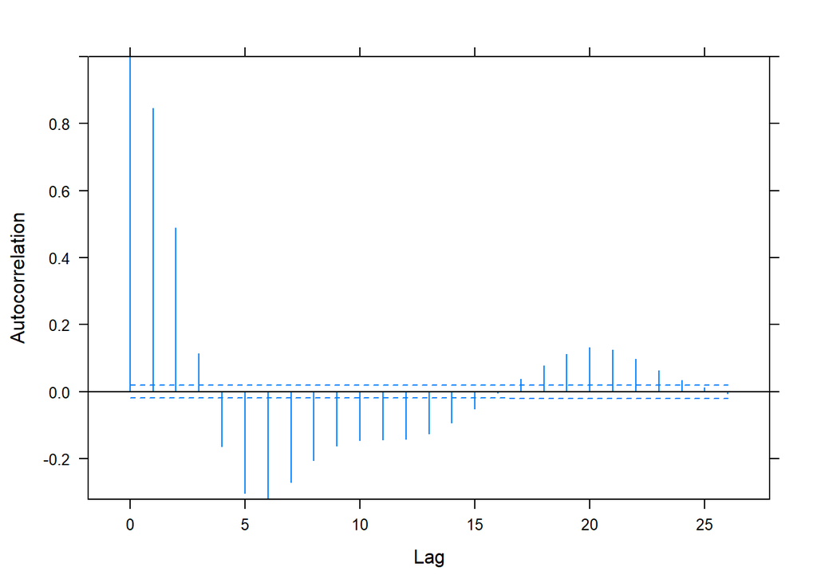

```r
plot(ACF(model, resType="normalized"), alpha=0.05)
```

Adding an autoregresive order 1 with correlation structure set to 0.3. Toto je default u `fmri` balíku.

```r
model_ar1 <- lme(filt_mot_33 ~ 0 + moving.learn + moving.trial + pointing.learn + pointing.trial,
             random = ~ 0 + moving.learn + moving.trial + pointing.learn + pointing.trial | participant,
             method="REML",
             data = df_all,
             control = nlme::lmeControl(rel.tol=1e-6),
             correlation = corAR1(value=0.3, form = ~1 | participant))
```

```r
summary(model_ar1)
```

```
## Linear mixed-effects model fit by REML
##  Data: df_all
##        AIC     BIC    logLik
##   5293.373 5409.36 -2630.687
##
## Random effects:
##  Formula: ~0 + moving.learn + moving.trial + pointing.learn + pointing.trial | participant
##  Structure: General positive-definite, Log-Cholesky parametrization
##                StdDev    Corr
## moving.learn   0.1891150 mvng.l mvng.t pntng.
## moving.trial   0.1237037  0.211
## pointing.learn 0.3050690 -0.509 -0.052
## pointing.trial 0.2679235 -0.596 -0.194  0.618
## Residual       0.6303431
##
## Correlation Structure: AR(1)
##  Formula: ~1 | participant
##  Parameter estimate(s):
##       Phi
## 0.8716913
## Fixed effects: filt_mot_33 ~ 0 + moving.learn + moving.trial + pointing.learn +      pointing.trial
##                     Value  Std.Error    DF   t-value p-value
## moving.learn   -0.2888521 0.04252358 10371 -6.792752       0
## moving.trial   -0.2748031 0.03112588 10371 -8.828766       0
## pointing.learn  0.5294910 0.07171439 10371  7.383330       0
## pointing.trial  0.4255312 0.05848475 10371  7.275935       0
##  Correlation:
##                mvng.l mvng.t pntng.l
## moving.trial    0.180
## pointing.learn -0.304  0.016
## pointing.trial -0.413 -0.059  0.488
##
## Standardized Within-Group Residuals:
##        Min         Q1        Med         Q3        Max
## -6.2060716 -0.4645565  0.1044343  0.7502765  5.6750045
##
## Number of Observations: 10400
## Number of Groups: 26
```

```r
out <- multcomp::glht(model_ar1, linfct=contrast)
summary(out)
```

```
##
##   Simultaneous Tests for General Linear Hypotheses
##
## Fit: lme.formula(fixed = filt_mot_33 ~ 0 + moving.learn + moving.trial +
##     pointing.learn + pointing.trial, data = df_all, random = ~0 +
##     moving.learn + moving.trial + pointing.learn + pointing.trial |
##     participant, correlation = corAR1(value = 0.3, form = ~1 |
##     participant), method = "REML", control = nlme::lmeControl(rel.tol = 1e-06))
##
## Linear Hypotheses:
##                                      Estimate Std. Error z value Pr(>|z|)
## movement.trial > movement.learn == 0  0.01405    0.04797   0.293    0.997
## movement > 0 == 0                    -0.56366    0.05704  -9.882   <1e-04 ***
## pointing.trial > pointing.learn == 0 -0.10396    0.06686  -1.555    0.381
## pointing > 0 == 0                     0.95502    0.11250   8.489   <1e-04 ***
## ---
## Signif. codes:  0 '***' 0.001 '**' 0.01 '*' 0.05 '.' 0.1 ' ' 1
## (Adjusted p values reported -- single-step method)
```

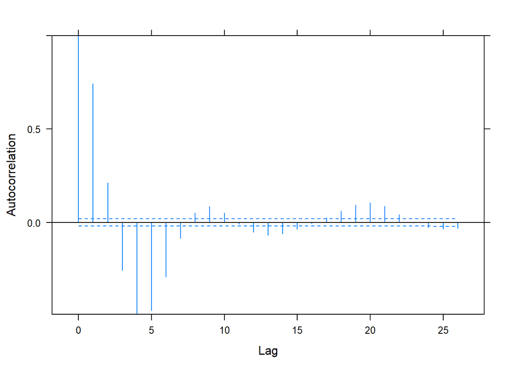

```r
plot(ACF(model_ar1, resType="normalized"), alpha=0.05)
```

Autokorelace nějaká zůstává, ale situace se zdá být trochu lepší a výsledky trochu odlišné.

A když modely porovnáme, autokorelovaný se zdá být obecně spolehlivější.

```r
anova(model, model_ar1)
```

```
##           Model df       AIC      BIC    logLik   Test  L.Ratio p-value
## model         1 15 19202.293 19311.03 -9586.146
## model_ar1     2 16  5293.373  5409.36 -2630.687 1 vs 2 13910.92  <.0001
```

Zatímco default je Autoregresive order 1 bez moving average, jiné články navrhují ARMA s AR 1 a MA také 1 (https://www.nature.com/articles/s41467-019-09230-w). Obojí jsem nastavil na korelační koef. 0.3.

```r
model_arma <- lme(filt_mot_33 ~ 0 + moving.learn + moving.trial + pointing.learn + pointing.trial,
             random = ~ 0 + moving.learn + moving.trial + pointing.learn + pointing.trial | participant,
             method="REML",
             data = df_all,
             control = nlme::lmeControl(rel.tol=1e-6),
             correlation = corARMA(value=c(0.3,0.3), p=1, q=1, form = ~1 | participant))
```

```r
summary(model_arma)
```

```
## Linear mixed-effects model fit by REML
##  Data: df_all
##         AIC       BIC   logLik
##   -6881.351 -6758.115 3457.676
##
## Random effects:
##  Formula: ~0 + moving.learn + moving.trial + pointing.learn + pointing.trial | participant
##  Structure: General positive-definite, Log-Cholesky parametrization
##                StdDev     Corr
## moving.learn   0.11859180 mvng.l mvng.t pntng.
## moving.trial   0.06845001  0.389
## pointing.learn 0.10577794 -0.706 -0.558
## pointing.trial 0.14167228 -0.814 -0.202  0.403
## Residual       0.63979262
##
## Correlation Structure: ARMA(1,1)
##  Formula: ~1 | participant
##  Parameter estimate(s):
##      Phi1    Theta1
## 0.8583080 0.9872197
## Fixed effects: filt_mot_33 ~ 0 + moving.learn + moving.trial + pointing.learn +      pointing.trial
##                     Value  Std.Error    DF   t-value p-value
## moving.learn   -0.2243331 0.02857796 10371 -7.849864       0
## moving.trial   -0.1607146 0.01994137 10371 -8.059361       0
## pointing.learn  0.2356602 0.03209689 10371  7.342151       0
## pointing.trial  0.2643738 0.03383554 10371  7.813494       0
##  Correlation:
##                mvng.l mvng.t pntng.l
## moving.trial    0.220
## pointing.learn -0.290 -0.210
## pointing.trial -0.502 -0.007  0.245
##
## Standardized Within-Group Residuals:
##         Min          Q1         Med          Q3         Max
## -6.10001794 -0.51906005  0.04543157  0.70048740  5.59118671
##
## Number of Observations: 10400
## Number of Groups: 26
```

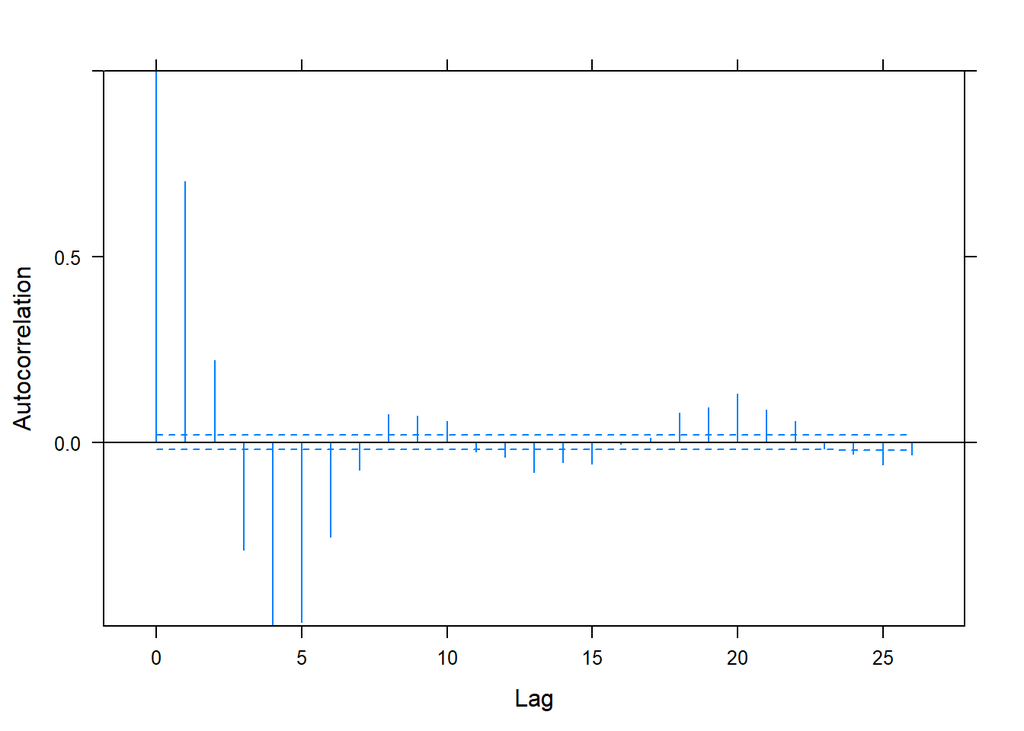

```r
plot(ACF(model_arma, resType="normalized"), alpha=0.05)
```

Zdá se, že to opravdu “řeší” model ještě lépe. Zatímco Phi je 0.85 (stejně jako u AR1) , theta je dokonce 0.98. Při porovnání anovou dostáváme jednoznačně nejlepší fit.

```r
anova(model, model_ar1, model_arma)
```

```
##            Model df       AIC       BIC    logLik   Test  L.Ratio p-value
## model          1 15 19202.293 19311.031 -9586.146
## model_ar1      2 16  5293.373  5409.360 -2630.687 1 vs 2 13910.92  <.0001
## model_arma     3 17 -6881.351 -6758.115  3457.676 2 vs 3 12176.73  <.0001
```

Aplikováním kýžených kontrastů na nový model pak dostáváme:

```r
out <- multcomp::glht(model_arma, linfct=contrast)
summary(out)
```

```
##
##   Simultaneous Tests for General Linear Hypotheses
##
## Fit: lme.formula(fixed = filt_mot_33 ~ 0 + moving.learn + moving.trial +
##     pointing.learn + pointing.trial, data = df_all, random = ~0 +
##     moving.learn + moving.trial + pointing.learn + pointing.trial |
##     participant, correlation = corARMA(value = c(0.3, 0.3), p = 1,
##     q = 1, form = ~1 | participant), method = "REML", control = nlme::lmeControl(rel.tol = 1e-06))
##
## Linear Hypotheses:
##                                      Estimate Std. Error z value Pr(>|z|)
## movement.trial > movement.learn == 0  0.06362    0.03103   2.050    0.142
## movement > 0 == 0                    -0.38505    0.03828 -10.058   <0.001 ***
## pointing.trial > pointing.learn == 0  0.02871    0.04052   0.709    0.912
## pointing > 0 == 0                     0.50003    0.05204   9.609   <0.001 ***
## ---
## Signif. codes:  0 '***' 0.001 '**' 0.01 '*' 0.05 '.' 0.1 ' ' 1
## (Adjusted p values reported -- single-step method)
```

Problém je pouze doba modelování, která je signifikatně pomalejší (cca 15 minut na jednu komponentu). Dá se zrychlit pomocí nastavení optimizačních koeficientů na “fixed”, tzn během optimizace se už na autokorelaci nesahá.

```r
model_arma_fixed <- lme(filt_mot_33 ~ 0 + moving.learn + moving.trial + pointing.learn + pointing.trial,
             random = ~ 0 + moving.learn + moving.trial + pointing.learn + pointing.trial | participant,
             method="REML",
             data = df_all,
             control = nlme::lmeControl(rel.tol=1e-6),
             correlation = corARMA(value=c(0.3,0.3), p=1, q=1, form = ~1 | participant, fixed=TRUE))
```

Ale při pohledu na AIC se fixed model zdá horší než běžná autokorelace bez MA.

```r
anova(model_arma_fixed, model_ar1, model_arma)
```

```
##                  Model df       AIC       BIC    logLik   Test   L.Ratio
## model_arma_fixed     1 15  8866.790  8975.527 -4418.395
## model_ar1            2 16  5293.373  5409.360 -2630.687 1 vs 2  3575.416
## model_arma           3 17 -6881.351 -6758.115  3457.676 2 vs 3 12176.725
##                  p-value
## model_arma_fixed
## model_ar1         <.0001
## model_arma        <.0001
```

## Závěr

- modeluji pouze ty eventy, které zabírají alespoň 50% doby pulsu (tzn pokud se člověk rozejde v čase 2.9, tak modeluji až od pulsu 2)
- používám separátně modelované HRF řady pro eventy v trial vs learn conditions
- propočty jsou zatím pro ARMA(1,0), mohu updatovat na ARMA(1,1), ale to bych raději počítal v nějakém výpočetním prostředí, kam zatím nemám přístup.
- používám mixed modely s random efektem všech proměnných vůči participantovi (tzn. každý participant má fitlý custom pro každý prediktor)